# Packages

Monika Peteva Petkova

mpetevap@uni-sofia.bg, monikapetevapetkova@gmail.com

2021

## Installing packages

R has a rich collection of packages. They allow researchers to share R functions and data. You can install packages available in the **CRAN** repository using `install.packages`. We already learned how we can get help

```r
> ?install.packages
> help("install.packages")
```

You can also install packages from the R Studio interface

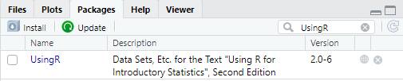

For the next tasks you will need to install `UsingR` and `MASS` packages available in the CRAN repository.

```r
> install.packages("UsingR")
> install.packages("MASS")
```

We can also install packages from **GitHub** using `install_github`. But first you need to install `devtools` from CRAN.

You can also see available packages using the `available.packages` or update a package using `update.packages` functions.

## Loading packages

Just because a package is installed on your computer does not mean that you have access to its functions. We need to load the package into the current R session. Getting help

```r
> ?library
```

Load the package in the memory

```r
> library(UsingR)
Warning: package 'UsingR' was built under R version 4.0.3
> library(MASS)
```

In R we have Warning and Error messages. Warning messages do not stop the flow of the function.

You can also use the `require` function to load a package.

## Session info

You can see information about your current session - R version, OS, attached or loaded packages and their versions using `sessionInfo`.

```r
> sessionInfo()
R version 4.0.2 (2020-06-22)
Platform: x86_64-w64-mingw32/x64 (64-bit)
Running under: Windows 10 x64 (build 19042)

Matrix products: default

locale:
[1] LC_COLLATE=Bulgarian_Bulgaria.1251  LC_CTYPE=Bulgarian_Bulgaria.1251
[3] LC_MONETARY=Bulgarian_Bulgaria.1251 LC_NUMERIC=C
[5] LC_TIME=Bulgarian_Bulgaria.1251

attached base packages:
[1] stats     graphics  grDevices utils     datasets  methods   base

other attached packages:
[1] UsingR_2.0-6    Hmisc_4.4-1     ggplot2_3.3.2   Formula_1.2-3
[5] survival_3.1-12 lattice_0.20-41 HistData_0.8-6  MASS_7.3-51.6

loaded via a namespace (and not attached):
 [1] tidyselect_1.1.0    xfun_0.16           purrr_0.3.4
 [4] splines_4.0.2       colorspace_1.4-1    vctrs_0.3.4
 [7] generics_0.0.2      htmltools_0.5.0     yaml_2.2.1
[10] base64enc_0.1-3     rlang_0.4.7         pillar_1.4.6
[13] foreign_0.8-80      glue_1.4.2          withr_2.3.0
[16] RColorBrewer_1.1-2  jpeg_0.1-8.1        lifecycle_0.2.0
[19] stringr_1.4.0       munsell_0.5.0       gtable_0.3.0
[22] htmlwidgets_1.5.2   evaluate_0.14       latticeExtra_0.6-29
[25] knitr_1.30          htmlTable_2.1.0     highr_0.8
[28] scales_1.1.1        backports_1.1.10    checkmate_2.0.0
[31] gridExtra_2.3       png_0.1-7           digest_0.6.25
[34] stringi_1.5.3       dplyr_1.0.2         grid_4.0.2
[37] tools_4.0.2         magrittr_1.5        tibble_3.0.3
[40] cluster_2.1.0       crayon_1.3.4        pkgconfig_2.0.3
[43] ellipsis_0.3.1      Matrix_1.2-18       data.table_1.13.0
[46] rmarkdown_2.4       rstudioapi_0.11     R6_2.4.1
[49] rpart_4.1-15        nnet_7.3-14         compiler_4.0.2
```

## Unloading packages

Sometimes you need to unload a package.

```r
> detach("package:MASS")
```

## Uninstalling packages

`remove.packages` remove installed packages.

```r
> remove.packages("MASS")
```

## Example

Next are considered examples with `mtcars` data frame from `datasets` package.

```r
> head(mtcars)
```

```
                   mpg cyl disp  hp drat    wt  qsec vs am gear carb
Mazda RX4         21.0   6  160 110 3.90 2.620 16.46  0  1    4    4
Mazda RX4 Wag     21.0   6  160 110 3.90 2.875 17.02  0  1    4    4
Datsun 710        22.8   4  108  93 3.85 2.320 18.61  1  1    4    1
Hornet 4 Drive    21.4   6  258 110 3.08 3.215 19.44  1  0    3    1
Hornet Sportabout 18.7   8  360 175 3.15 3.440 17.02  0  0    3    2
Valiant           18.1   6  225 105 2.76 3.460 20.22  1  0    3    1
```

Wring `?` before the name of the data frame gives information about the data frame, if it is available.

```r
> ?mtcars
```

You can see what is this data frame about and some information about the data contained in the columns.

As we already saw we can use `dim`,`nrow` and `ncol` to show the dimensions of the data frame

```r
> dim(mtcars)
[1] 32 11
> nrow(mtcars)
[1] 32
> ncol(mtcars)
[1] 11
```

Next different ways to take only part of the data frame are reviewed.  
Shows the element in the 1 row, 2 column

```r
> mtcars[1, 2]
[1] 6
```

Shows the element in the “Mazda RX4” row, “cyl” column

```r
> mtcars["Mazda RX4", "cyl"]
[1] 6
```

Shows the elements in the 9 column

```r
> mtcars[[9]]
 [1] 1 1 1 0 0 0 0 0 0 0 0 0 0 0 0 0 0 1 1 1 0 0 0 0 0 1 1 1 1 1 1 1
```

Shows the element in the “am” column

```r
> mtcars[["am"]]
 [1] 1 1 1 0 0 0 0 0 0 0 0 0 0 0 0 0 0 1 1 1 0 0 0 0 0 1 1 1 1 1 1 1
```

Shows the element in the “am” column

```r
> mtcars$am
 [1] 1 1 1 0 0 0 0 0 0 0 0 0 0 0 0 0 0 1 1 1 0 0 0 0 0 1 1 1 1 1 1 1
```

## Attach data frame

Taking the names of the columns in the data frame

```r
> names(mtcars)
 [1] "mpg"  "cyl"  "disp" "hp"   "drat" "wt"   "qsec" "vs"   "am"   "gear"
[11] "carb"
```

Let’s say we want to take the `mpg` column, we can use `$` after the data frame’s name

```r
> mtcars$mpg
 [1] 21.0 21.0 22.8 21.4 18.7 18.1 14.3 24.4 22.8 19.2 17.8 16.4 17.3 15.2 10.4
[16] 10.4 14.7 32.4 30.4 33.9 21.5 15.5 15.2 13.3 19.2 27.3 26.0 30.4 15.8 19.7
[31] 15.0 21.4
```

or to attach the data frame and only to write the name of the column.

```r
> attach(mtcars)
> mpg
 [1] 21.0 21.0 22.8 21.4 18.7 18.1 14.3 24.4 22.8 19.2 17.8 16.4 17.3 15.2 10.4
[16] 10.4 14.7 32.4 30.4 33.9 21.5 15.5 15.2 13.3 19.2 27.3 26.0 30.4 15.8 19.7
[31] 15.0 21.4
```

`attach` loads the data frame, so it is not necessary to write the data frame’s name in front of the column name.  
Getting help

```r
> ?attach
```

Sometime this is very helpful, but it is important to notice that if you change the attached object the data frame is not going to change. For example let’s change the first value

```r
> mpg[1] = 200
> mpg
 [1] 200.0  21.0  22.8  21.4  18.7  18.1  14.3  24.4  22.8  19.2  17.8  16.4
[13]  17.3  15.2  10.4  10.4  14.7  32.4  30.4  33.9  21.5  15.5  15.2  13.3
[25]  19.2  27.3  26.0  30.4  15.8  19.7  15.0  21.4
> mtcars$mpg
 [1] 21.0 21.0 22.8 21.4 18.7 18.1 14.3 24.4 22.8 19.2 17.8 16.4 17.3 15.2 10.4
[16] 10.4 14.7 32.4 30.4 33.9 21.5 15.5 15.2 13.3 19.2 27.3 26.0 30.4 15.8 19.7
[31] 15.0 21.4
```